# Yield prediction of various farm processing units

## *Abstract*

> Supply chain management is an integral part of any business to maintain the transformation of raw materials to finished goods and services. It helps to maximize the customer value and gain advantage in the marketplace. For years, suppy chain management has helped businesses flourish and create a brand value in the marketplace.

> Businesses have been implementing supply chain management with the help of tradtional, paper-based methods. With the help of *data science*, businesses have not only optimized this process and get better predictions, but also capture real-time decisions to significantly improve the stratergies and performance metrics.

> Supply chain management produces benefits like enhanced strategies, lower operating costs, higher profits and increased collaborations.

### *Introduction*

> This report outlines the findings of the `train_data`, `farm_data` and `train_weather` data analysis that has been performed as a part of the curriculum at **International School of Engineering (INSOFE)**, under the module **CSE 9099c_PHD (Project Hackathon and Defense (PHD)).**

### *Key Documents*

> The data received for the analysis is as follows:
> 1. `train_data.csv` : It consists information about the yield of each ingredient produced by each farm on a daily basis.
> 2. `farm_id.csv` : It consists of the description of each farm and the deidentified location.
> 3. `train_weather.csv` : It consists of the information of hourly weather conditions of each day for the year 2016.

### *Methods*

> Before starting the analysis, we have **merged** all the three dataframes using Python functions.  
> The graphs and plots present in this report are made using TABLEAU and Python's data visualization libraries. TABLEAU gives flexibility to visualize multiple plots at once and hence extract information from the user-friendly API.

**The merging of the dataframe has been done is a separately. We will only be importing the `final dataframe` in this notebook, specifcally for data visualization.**

```python
# Importing the required libraries for basic python operations and to read the dataframes
import numpy as np
import pandas as pd

# Importing the data visualization libraries
import matplotlib.pyplot as plt
import seaborn as sns

%matplotlib inline
```

#### Importing the dataframe

```python
# Reading the dataframe
data = pd.read_csv('final_merger.csv',parse_dates = ['DATE'])
```

```python
data.head()
```

|  | DATE | deidentified_location | temp_obs | cloudiness | wind_direction | dew_temp | pressure_sea_level | precipitation | wind_speed | farm_id | ingredient_type | yield | farm_area | farming_company |
| --- | --- | --- | --- | --- | --- | --- | --- | --- | --- | --- | --- | --- | --- | --- |
| 0 | 2016-01-01 | location 1784 | -12.8 | 0.0 | 280.0 | -16.7 | 1036.0 | 0.0 | 3.1 | fid_107641 | ing_w | 2007.5009 | 6913.841260 | Obery Farms |
| 1 | 2016-01-01 | location 1784 | -12.8 | 0.0 | 280.0 | -16.7 | 1036.0 | 0.0 | 3.1 | fid_107641 | ing_z | 146.3537 | 6913.841260 | Obery Farms |
| 2 | 2016-01-01 | location 1784 | -12.8 | 0.0 | 280.0 | -16.7 | 1036.0 | 0.0 | 3.1 | fid_113732 | ing_w | 1311.3707 | 3294.804895 | Dole Food Company |
| 3 | 2016-01-01 | location 1784 | -12.8 | 0.0 | 280.0 | -16.7 | 1036.0 | 0.0 | 3.1 | fid_116101 | ing_w | 1549.7511 | 4834.114702 | Dole Food Company |
| 4 | 2016-01-01 | location 1784 | -12.8 | 0.0 | 280.0 | -16.7 | 1036.0 | 0.0 | 3.1 | fid_116743 | ing_w | 996.7503 | 6259.525431 | Obery Farms |

```python
# Checking the shape of the data
data.shape
```

```
(850397, 14)
```

```python
data.describe(include = 'all')
```

|  | DATE | deidentified_location | temp_obs | cloudiness | wind_direction | dew_temp | pressure_sea_level | precipitation | wind_speed | farm_id | ingredient_type | yield | farm_area | farming_company |
| --- | --- | --- | --- | --- | --- | --- | --- | --- | --- | --- | --- | --- | --- | --- |
| count | 850397 | 850397 | 850397.000000 | 850397.000000 | 850397.000000 | 850397.000000 | 850397.000000 | 850397.000000 | 850397.000000 | 850397 | 850397 | 8.503970e+05 | 850397.000000 | 850397 |
| unique | 366 | 16 | NaN | NaN | NaN | NaN | NaN | NaN | NaN | 1434 | 4 | NaN | NaN | 16 |
| top | 2016-12-27 00:00:00 | location 2532 | NaN | NaN | NaN | NaN | NaN | NaN | NaN | fid_63700 | ing_w | NaN | NaN | Obery Farms |
| freq | 2383 | 114526 | NaN | NaN | NaN | NaN | NaN | NaN | NaN | 2928 | 504247 | NaN | NaN | 343236 |
| first | 2016-01-01 00:00:00 | NaN | NaN | NaN | NaN | NaN | NaN | NaN | NaN | NaN | NaN | NaN | NaN | NaN |
| last | 2016-12-31 00:00:00 | NaN | NaN | NaN | NaN | NaN | NaN | NaN | NaN | NaN | NaN | NaN | NaN | NaN |
| mean | NaN | NaN | 15.434140 | 2.644226 | 171.794344 | 7.693794 | 1016.103504 | 0.611968 | 3.284427 | NaN | NaN | 5.052799e+04 | 9978.833538 | NaN |
| std | NaN | NaN | 10.415634 | 2.759813 | 94.204147 | 10.075720 | 6.761272 | 5.830237 | 1.633880 | NaN | NaN | 3.560156e+06 | 10858.837204 | NaN |
| min | NaN | NaN | -26.250000 | 0.000000 | 0.000000 | -32.050000 | 975.650000 | -1.000000 | 0.000000 | NaN | NaN | 0.000000e+00 | 26.291549 | NaN |
| 25% | NaN | NaN | 8.600000 | 0.000000 | 100.000000 | 0.300000 | 1012.000000 | 0.000000 | 2.100000 | NaN | NaN | 5.339700e+02 | 2996.679168 | NaN |
| 50% | NaN | NaN | 16.650000 | 2.000000 | 170.000000 | 8.300000 | 1015.800000 | 0.000000 | 3.100000 | NaN | NaN | 2.073951e+03 | 6706.946279 | NaN |
| 75% | NaN | NaN | 23.300000 | 4.000000 | 250.000000 | 15.850000 | 1020.250000 | 0.000000 | 4.100000 | NaN | NaN | 6.704650e+03 | 12876.541606 | NaN |
| max | NaN | NaN | 39.150000 | 9.000000 | 350.000000 | 25.000000 | 1044.550000 | 217.000000 | 14.500000 | NaN | NaN | 4.611469e+08 | 81290.125000 | NaN |

```python
data['month'] = pd.to_datetime(data['DATE']).dt.month
```

## Data Visualization

#### Correlation Heatmap

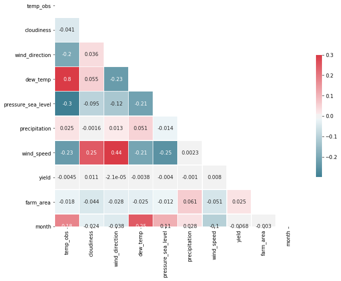

```python
corr = data.corr()

# Generate a mask for the upper triangle
mask = np.zeros_like(corr, dtype=np.bool)
mask[np.triu_indices_from(mask)] = True

# Set up the matplotlib figure
f, ax = plt.subplots(figsize=(11, 9))

# Generate a custom diverging colormap
cmap = sns.diverging_palette(220, 10, as_cmap=True)

# Draw the heatmap with the mask and correct aspect ratio
sns.heatmap(corr, mask=mask, cmap=cmap, vmax=.3, center=0, annot = True,
            square=True, linewidths=.5, cbar_kws={"shrink": .5})
```

Ref: https://seaborn.pydata.org/examples/many_pairwise_correlations.html

The heatmap above shows the correlation between each of the features with `yield`. The correlationship of `yield` with other features are very low.

However, the correlation of `temp_obs` and `dew_temp` is about *80%*. This signifies that these two features possesses **multicollinearity**. We may drop one of the columns in the future data engineering steps.

#### SCATTER PLOT for `farm_area` v/s `yield`

By looking at the features, I could see a feature, `farm_area`. Intutively, the first inference I made was that the `farm_area` is postively related to the `yield`. However, the correlation plot stated that `farm_area` had only *2.5%* correlation with yield.

This proved my intuition incorrect. Although for further analysis, I have plotted below the scatter plots.

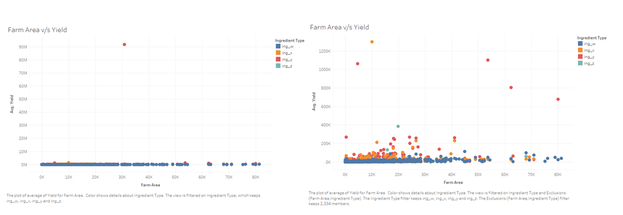

```
                                                                                                  Plotted using TABLEAU
```

Inferences from `plot 1`:

- We can see a **potential outlier** of ingredient `ing_y`. This could hamper our predictions while model building.

Inferences from `plot 2`:

- For instance, I have removed the potential outlier to see the spread of the data. We can see that there are a lot of instances which have yields less than 50k. This could possibly influence our predictions.
- We can also see that for `farm_area` greater than 50k, there are instances for which the `yield` is less than 50k.

To verify this, we shall be plotting a *boxplot* in the coming steps.

#### BOXPLOT

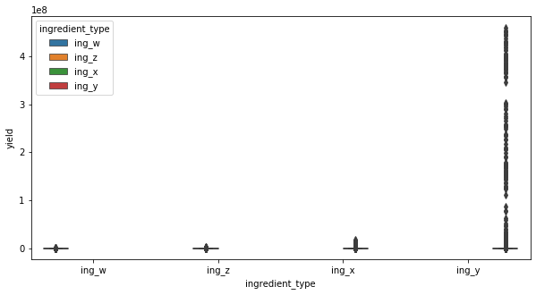

```python
plt.figure(figsize = (10,5))

# Plotting BOXPLOT
sns.boxplot(x = 'ingredient_type', y = 'yield', data = data, hue = 'ingredient_type')
```

Hence, we shall be retaining this for our model building.

#### BAR PLOT and COUNT PLOT

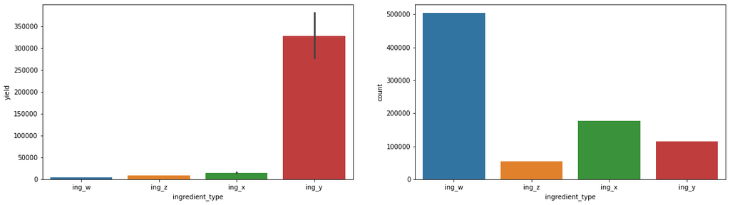

```python
# Plot multiple plots in a single markdown cell
plt.figure(figsize = (19,5))

# For plot 1, BAR PLOT
plt.subplot(121)
sns.barplot(x = 'ingredient_type', y = 'yield', data = data)

# For plot 2, COUNT PLOT
plt.subplot(122)
sns.countplot(x = 'ingredient_type', data = data)
```

In the above plots, we see that of all the ingredients:

1. `ing_y` has the maximum yield (1st plot)
2. `ing_w` has the maximum number of reported yield in the data (2nd plot)

#### STACKED AND UNSTACKED BARPLOTS

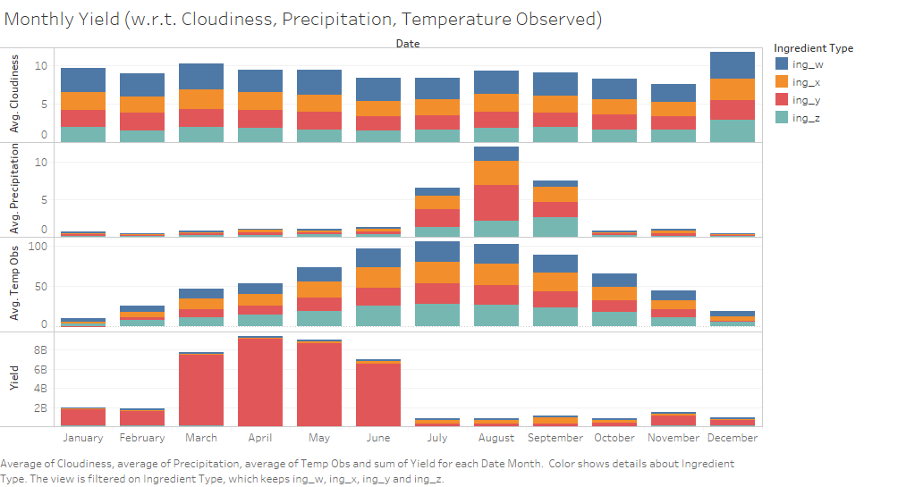

```
                                                                                                  Plotted using TABLEAU
```

The above plot shows the *monthly yield* of each ingredient over the year **2016**. By looking at the graph:

Due to dominance of the yield of ingredient `ing_y`, it is challenging to extract inferences of other ingredients.

Hence, below I have broken down the plots according to the `ingredient type.`

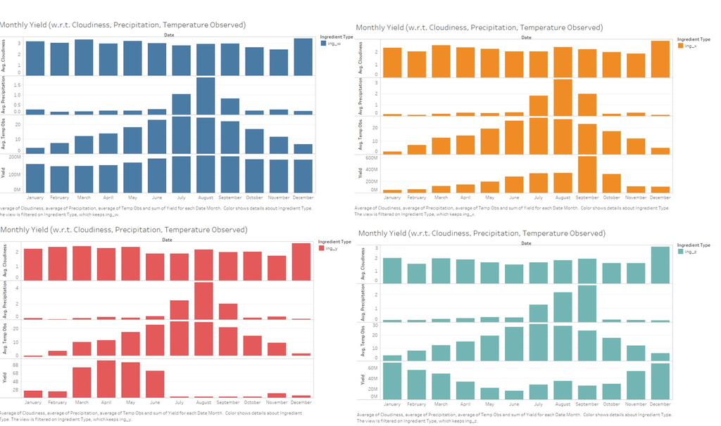

```
                                                                                                  Plotted using TABLEAU
```

#### Common inferences from the above plots:

By looking at the above weather conditions, the regions at which these ingredients are grown are possibly from the **Northern Hemisphere**, where summers are witnessed from *July* to *September*.

**- By looking at the above weather conditions, the regions, or as mentioned as a feature `deidentified_location`, at which these ingredients are grown are possibly from the **Northern Hemisphere**, where summers are witnessed from _July_ to _September_.**

Ref: https://en.wikipedia.org/wiki/Earth_rainfall_climatology

#### Inferences for `ing_w`:

1. There is all-year long yield.
2. The yield maximizes between the months *June and September.*

#### Inferences for `ing_x`:

1. The harvesting season starts from *July* and goes on to *October* to give maximum yield.

#### Inferences for `ing_y`:

1. `ing_y` has a different behavior. It witnesses maximum yields from the month of *March* to *June*.
2. From *March* to *June*, it is *spring season* in the northen hemisphere. So we can say that `ing_y` is a spring-season crop.

#### Inferences for `ing_z`:

1. It can be seen that even `ing_z` possesses a different behavior. The harvesting season starts from *November* and concludes in *March*.

## Quality of data

- Inferring that the crops are seasonal, it is challeging to predict the trend and randomness due to lack of data. The data only consisted of year **2016**. Had we had more past data, we would have been easy for us to explore trend(s).
- In the original dataframes(`farm_id.csv` and `train_weather.csv`), there were a lot of **NULL** values. These values/features were either droppped or be imputed using `fillna()`.
- Overall, the data could be understood and a lot of inferences could be made out of them.